# CUBI advanced R bioinformatics course / 02

2020-05-29

## Tidyverse

## Why tidyverse

- Cleaner code
- Useful automatisation
- Great data processing language
- Coherent structure of packages

## Why *not* tidyverse

- Changes the logic of the language
- Makes your code depend on tidyverse
- Fewer people will understand your code
- Easy things are even easier, hard things are even harder
- Useful mostly for data frames and lists (but that's not entirely true)

## My god, it's full of packages

[figure not shown]

## Tidyverse packages

| Package | What does it do | What does it replace / introduce |
| --- | --- | --- |
| rlang | Main tidyverse framework, a redefinition of R | A lot of base R constructs; introduces quosures |
| tibble | New model of data frames | data frames |
| dplyr | Main data frame manipulation tool | data frame operations |
| tidyr | Manipulating data formats, pivoting | e.g. reshape & co |
| magrittr | Introducing pipes to R | The `%>%` operator & co |
| purrr | Functional constructs | lapply, sapply & co |
| readr | read and write data frames | read.table & co |
| forcats | dealing with factors | introduces goodies for working with factors |
| stringr | dealing with strings | introduces goodies for working with strings |
| broom | standardizing output of common functions | `summary()` |
| ggplot2 | Graphics based on "Grammar of graphics" | replaces base plotting utilities |

## How to use tidyverse

- load with `library(tidyverse)`
- some packages (e.g. `magrittr`) need to be loaded separately
- never load `plyr` after `dplyr`

## Introducing Pipes

## Introducing Pipes

In R, almost everything is a function, but some functions are special: they look like operators.

```r
vec <- 1:10
`[`(vec, 2)
```

```
## [1] 2
```

```r
`+`(1, 2)
```

```
## [1] 3
```

## Introducing Pipes

It is possible to create your own functions which work like operators.

```r
`%cup%` <- function(x, y) union(x, y)
1:10 %cup% 2:15
```

```
##  [1]  1  2  3  4  5  6  7  8  9 10 11 12 13 14 15
```

```r
`%cap%` <- function(x, y) intersect(x, y)
1:10 %cap% 2:15
```

```
## [1]  2  3  4  5  6  7  8  9 10
```

The names for the operators here come from the \(\LaTeX\) symbol names for mathematical set operators \(\cup\) ("cup") and \(\cap\) ("cap").

## Introducing Pipes

How about an operator that calls just any function?

```r
a %>% some_func(b)

## is the same as

`%>%`(a, some_func(b))

## is the same as
some_func(a, b)
```

## Introducing Pipes

Pipes work for *anything*, not just the tidyverse!

```r
df <- data.frame(1:1000)

df %>% head
```

```
##   X1.1000
## 1       1
## 2       2
## 3       3
## 4       4
## 5       5
## 6       6
```

## Ceci n'est pas une pipe

[figure not shown]

## Ceci n'est pas une pipe

Magrittr defines a number of aliases – and of course the pipe operator, `%>%`. However, there is more to this package.

- aliases (extract, set_names etc.)
- `%$%` operator (pipe version of `attach`)

(Demo)

## Simple demonstration

(Demo)

## Other concepts and packages

- ggplot2: the tidyverse way of plotting
- (r)markdown / knitr: clean documentation

## Introducing tibbles

## So many ways to skin a cat

data.frame has so many problems. Luckily, there are also so many solutions.

- data.table / DT
- DataFrame
- tibble (tidyverse, formerly known as data_frame)
- special objects (ExpressionSet etc.)

## What is special about tibble

- Hadley Wickham hates row names
- tbl[,3] returns a tbl rather than a vector
- nicer printing
- extra properties (`group_by` etc.)

(Demo)

## Fine, but…

If you want to view more than the default portion of the tibble, do

```r
print(starwars, n=Inf, width=Inf)
```

Row names: convert them to a column, use filter() instead of `[`

## Reading data with readr

- read_{tsv,csv,…}, write…
- better, cleaner, faster
- explicit
- will never turn a string into a factor

## dplyr

## dplyr: managing data

- select, mutate, filter, rename, pull, arrange
- distinct, sample_{n,frac}, add_count, add_tally
- summarise, _at, _if
- group_by

(Demo)

## select

Select columns from data:

```
mtcars %>% select(mpg)
mtcars %>% select(mpg, Cylinder=cyl)
mtcars %>% select(starts_with("d"))
```

## mutate

Create new columns

```
mtcars %>% mutate(lp100km=282.5/mpg)
```

## filter

Select rows from the data

```
mtcars %>% filter(hp > 100)
mtcars %>% filter(hp > 100 & cyl < 8)
```

## pull

Get a single column as a vector

```
mtcars %>% pull(mpg)
```

## arrange

Sort the rows of the data

```
mtcars %>% arrange(mpg)
```

## tidyr

## Long vs wide data

`gather()`, `spread()`

(Demo)

## group_by

Essentially, add information to the tibble that the data is grouped by a variable. This does not change the actual data!

```r
identical(table2, table2 %>% group_by(country))
```

```
## [1] FALSE
```

```r
identical(as.data.frame(table2),
          as.data.frame(table2 %>% group_by(country)))
```

```
## [1] TRUE
```

You can then use several other functions.

(Demo)

## Use with caution!

While tidyverse is great for interactive work, you should use it with caution in your packages:

```r
foo <- function(df) {
  cols <- c("sex", "age")
  df %<>% select(cols)

  # ... do something

  return(df)
}
```

What happens when df contains `cols`?

(Demo)

## Solution

Be wary of tidyverse shortcuts. Always assume the worst case scenario and be explicit in your code:

```r
# make sure you select columns from variable
# and not by name
df %<>% select(!!cols)
```

## Mapping

## Mapping in R / in R + tidyverse

```r
tmp <- list(a=1, b=2, c=1:10)

lapply(tmp, length)
```

```
## $a
## [1] 1
##
## $b
## [1] 1
##
## $c
## [1] 10
```

```r
lapply(tmp, function(x) paste(x, collapse=", "))
```

```
## $a
## [1] "1"
##
## $b
## [1] "2"
##
## $c
## [1] "1, 2, 3, 4, 5, 6, 7, 8, 9, 10"
```

## Mapping in R / in R + tidyverse

```r
map(tmp, ~ paste(., collapse=", "))
```

```
## $a
## [1] "1"
##
## $b
## [1] "2"
##
## $c
## [1] "1, 2, 3, 4, 5, 6, 7, 8, 9, 10"
```

```r
## type conversion is always specified
map_chr(tmp, ~ paste(., collapse=", "))
```

```
##                               a                               b                               c
##                             "1"                             "2" "1, 2, 3, 4, 5, 6, 7, 8, 9, 10"
```

## Why both worlds?

- The *pply functions are still widely used, so you will see them in code
- sometimes using tidyverse does not really give you a bonus

## lapply & sapply

`sapply` takes a list and tries to simplify it to a relevant object (data frame, vector etc.) Notably, it uses names of the list, and you can force it to always return a list.

Compare:

```r
lapply(starwars$name, nchar)
sapply(starwars$name, nchar)
sapply(starwars$name, nchar, simplify=FALSE)
```

(Demo)

## `replicate`

This is a special form of `sapply` which simply calls a function `n` times and returns the results in a list. Note that it uses an expression and not a function as a second argument.

```
## create 10 vectors with random numbers
replicate(10, rnorm(10), simplify=FALSE)
```

## General form

```
xxxapply(data, ..., function)
```

Where `function` can be a closure (anonymous function), defined in place:

```
## replace spaces by underscores
sapply(starwars$name,
  function(x)
      gsub(" ", "_", starwars$name))
```

## apply

`apply` is for data frames and matrices (two-dimensional objects). The second argument determines whether it works row-wise (1) or column-wise (2):

```
## matrix of random numbers, 3 x 20
mtx <- matrix(rnorm(60), ncol=3)

apply(mtx, 1, sum)
apply(mtx, 2, sum)
```

## There is a simpler way

Don't forget following convenience functions:

- `colSums`, `colMeans`
- `rowSums`, `rowMeans`

## tapply

`tapply` applies a function to vector split by levels of a factor. For example, we might want to know what is the mean mpg for cars with different number of cylinders:

```
tapply(mtcars$mpg, mtcars$cyl, mean)
```

This is a really important function.

## Mapping in dplyr

## `group_by`

`group_by` introduces a grouping in a data frame that can be then used by `summarise` to calculate something reasonable. This is a lot like `tapply`.

```
mtcars %>% group_by(cyl) %>%
  summarise(m.hp=mean(hp))
```

## `group_by`

This has the advantage that you can define a whole range of calculations based on any column in the data:

```
mtcars %>% group_by(cyl) %>%
  summarise(m.hp=mean(hp), m.wt=mean(wt))
```

Or you can use a more complex function:

```
## which planet has the largest mean BMI?
starwars %>% group_by(homeworld) %>%
  summarise(bmi = mean(mass/(height/100)^2))
```

## `purrr`

## `map` and co.

`map` works very much like `sapply(..., simplify=F)`, and its variants explicitely try to cast the result in an appriopriate format.

- `map_lgl` – logical vector
- `map_chr` – character vector
- `map_int` – integer vector
- `map_dbl` – double (floating point) vector

## The weird syntax of `map`

To make the map functions more terse, map family adopted a particular way of formulating custom functions. `.` (dot) is automatically used as argument, and instead of writing `function(x) ...` you write `~ ...`:

- sapply:

  ```
  ## return 1, 2, ... 10 random numbers
  sapply(1:10, function(x) rnorm(x))
  ```

- map:

  ```
  map(1:10, ~ rnorm(.))
  ```

## Formula notation in dplyr

The same notation can be used also in dplyr with the `mutate_all` and `rename_all` functions:

```
## Replace "none" by NA
starwars %>% mutate_all(~ gsub("none", NA, .))

## Modify all variable names
starwars %>% rename_all(~ paste0("Var_", .))
```

## `map_dfr` and `map_dfc`

These two create a data frame. If your function returns each time a data frame, map will join these – either by rows (`map_dfr`) or by columns (`map_dfc`).

```
## create a list with 10 random vectors
rv <- map(1:10, ~ rnorm(10))
names(rv) <- LETTERS(1:10)

## calculate the mean and sd
map_dfc(rv, ~ data.frame(mean=mean(.), sd=sd(.)))
```

## `map2` et co.

Sometimes you want to go over two or more vectors at the same time. Instead of `.` you have two automatic variable names, `.x` and `.y`.

```
## add number of vehicles to each name
sw_names <- starwars$name
sw_vehcls <- starwars$vehicles
map2_chr(sw_names, sw_vehcls,
  ~ paste0(.x, "_", length(.y)))
```

## `pmap` and co.

You can also use `pmap` to apply it to a list of vectors in which each vector has the same length. But remember: data.frame is also a list! So you can apply pmap to a data frame and process each row.

```
starwars %>%
  select(name, hair_color, eye_color) %>%
  mutate_all(~ gsub("none", NA, .)) %>%
  drop_na() %>%
  pmap_chr(~ sprintf("%s has %s hair and %s eyes", ...))
```

## Principles of data presentation

## Edward Tufte

“Graphical excellence is that which  
gives to the viewer the greatest number of ideas in the shortest time with the least ink in the smallest space.”

## Less is more

Data visualization is all about communication.

Just like in graphics design, less is more. To get a good graphics remove all excess ink.

## Average MPG depending on number of cylinders

```r
p <- mtcars %>% group_by(cyl) %>%
      summarise(mean_mpg=mean(mpg)) %>%
      mutate(cyl=factor(cyl)) %>%
      ggplot(aes(x=cyl, y=mean_mpg, fill=cyl))
p + geom_bar(stat="identity", mapping=aes(fill=cyl)) +
  theme(axis.line=element_line(size=1, arrow=arrow(length=unit(0.1, "inches"))))
```

## All bells and whistles

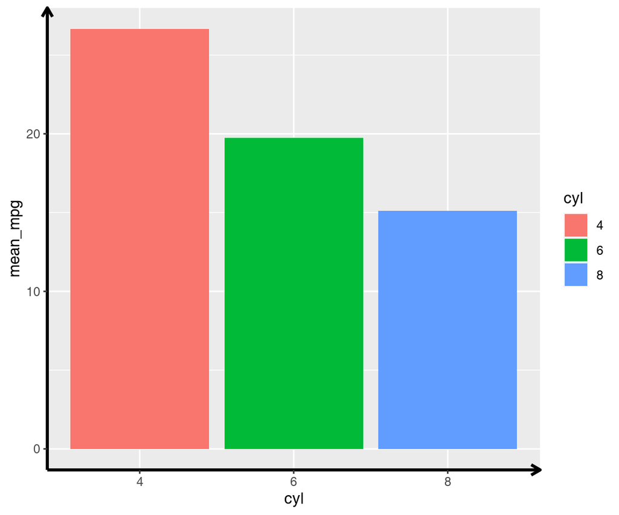

*“Clutter and confusion are failures of design, not attributes of information.”* (Tufte)

## Remove legend

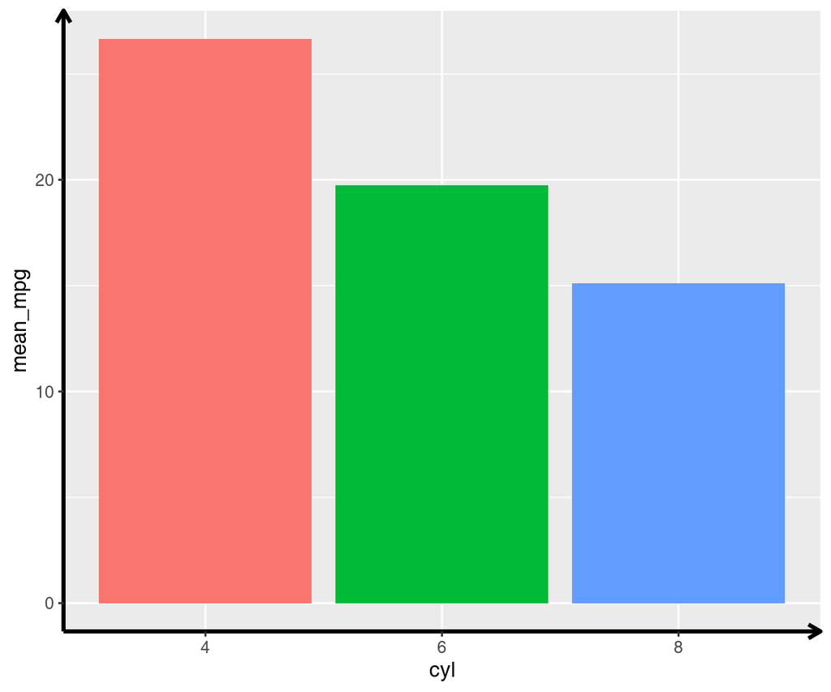

## Remove axes

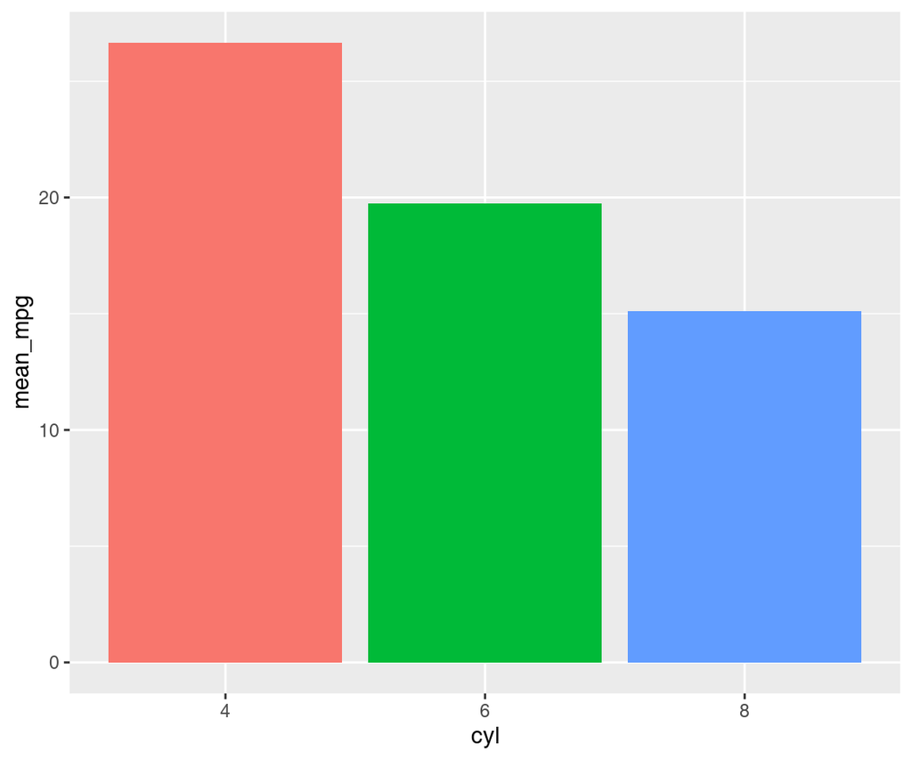

## Remove color

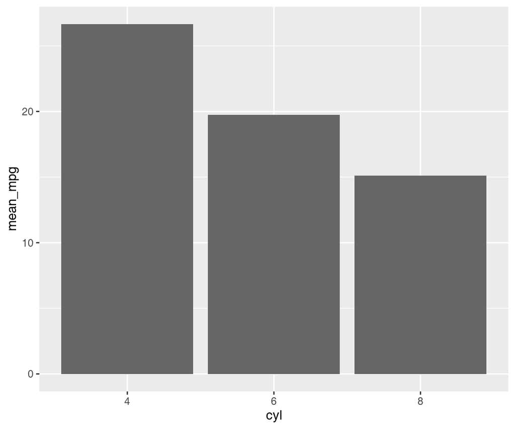

## Narrow bars

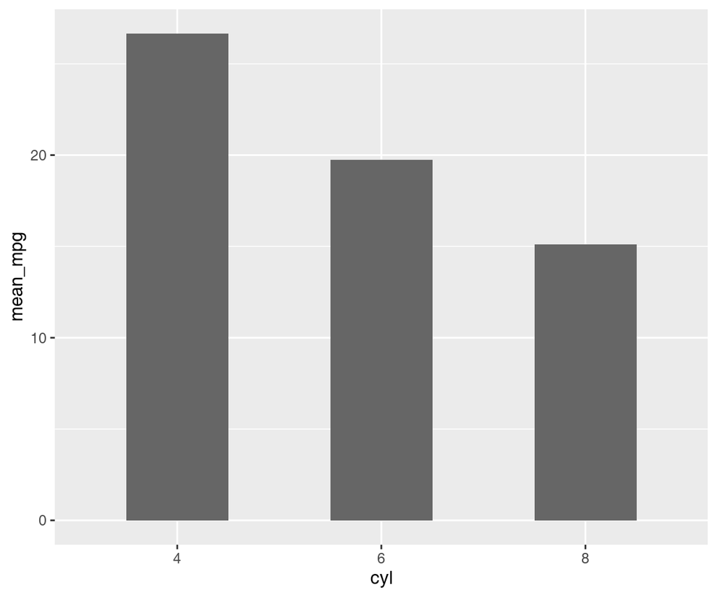

## Remove vertical grid

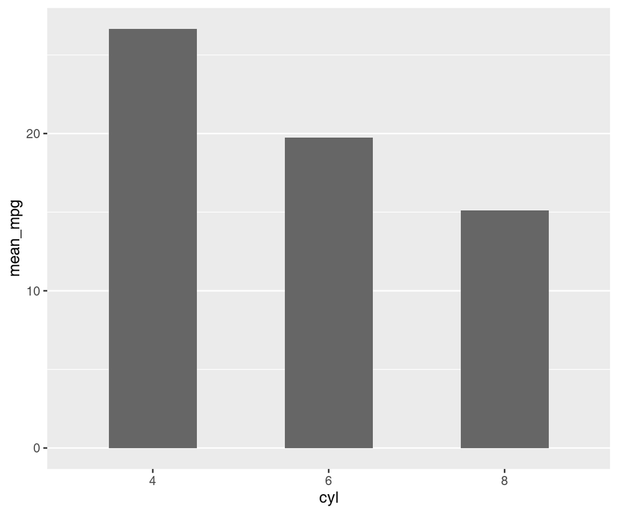

## Remove grey background

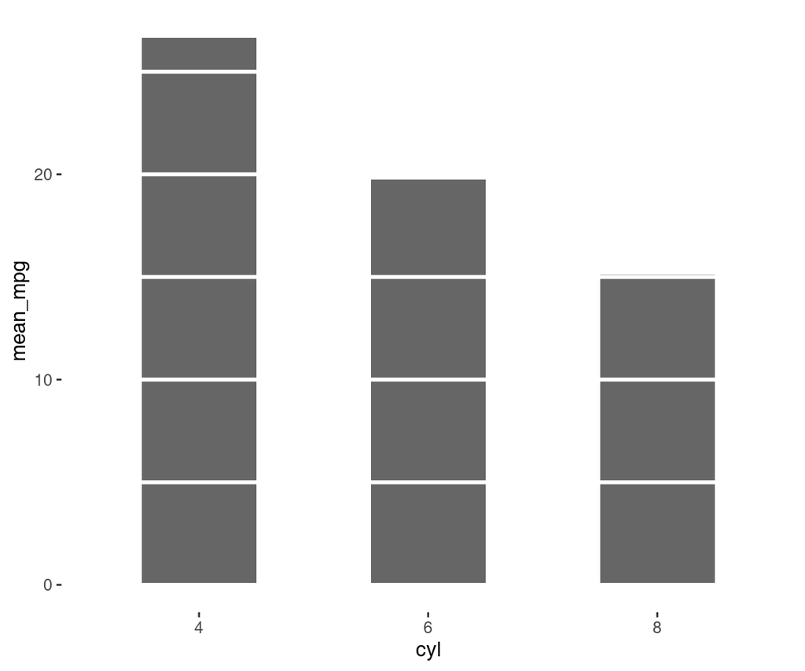

## Add meaningful labels

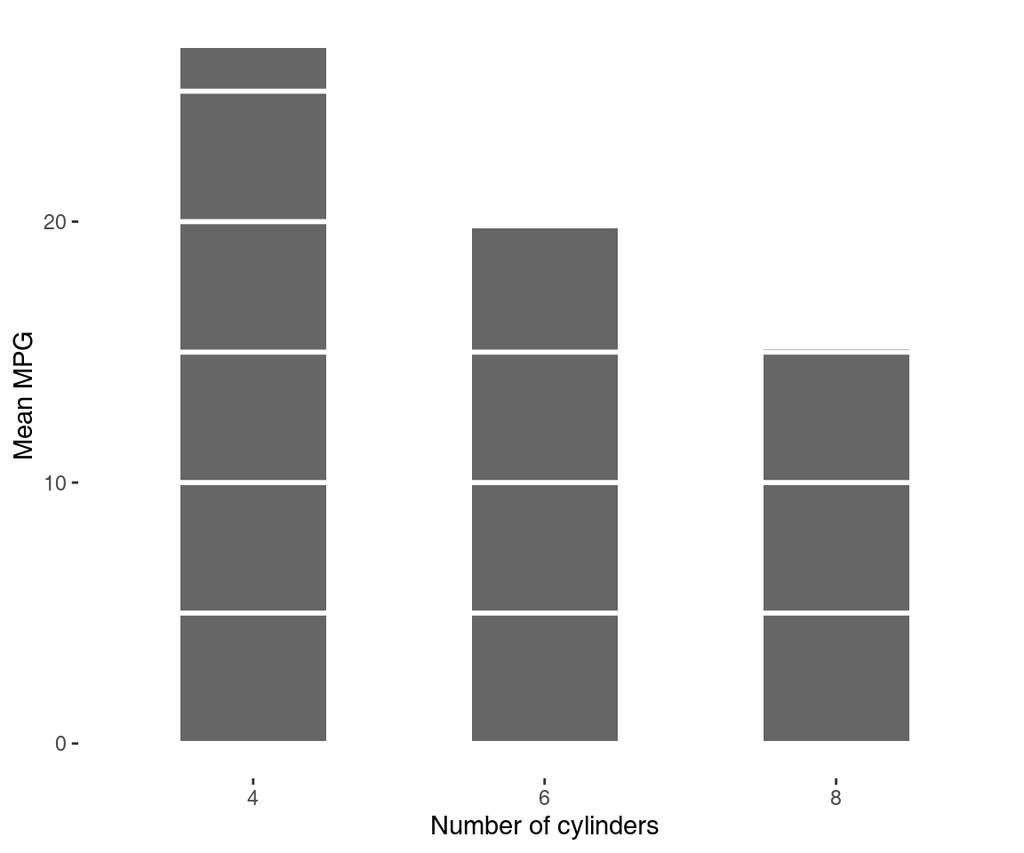

```
p + geom_bar(stat="identity", fill="#666666", width=0.5) +
  theme(legend.position="none",
    panel.grid.major.x=element_blank(),
    panel.ontop=T,
    panel.background=
        element_rect(fill="#FFFFFF00"),
    panel.grid.major.y=
        element_line(size=1, color="white"),
    panel.grid.minor.y=
        element_line(size=1, color="white")) +
    ylab("Mean MPG") +
    xlab("Number of cylinders")
```

## Box plots: default R

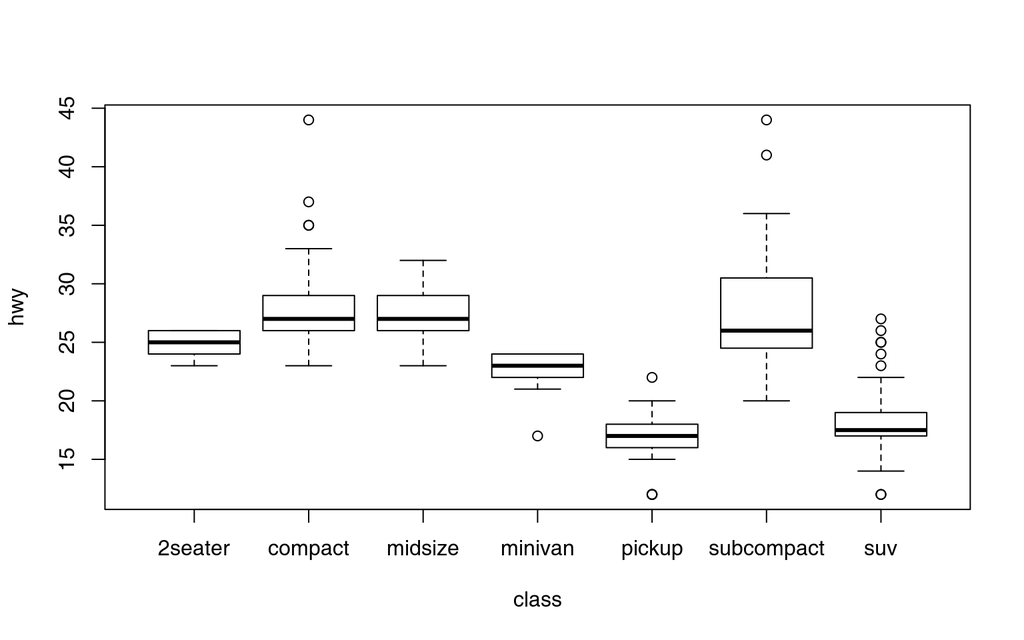

```r
boxplot(hwy ~ class, data=mpg)
```

## Box plots: Tufte

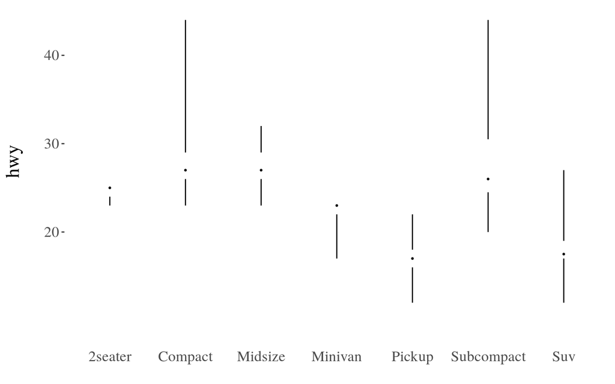

## Box plots: Tufte

```r
toupper1st <- function(x)
  paste0(toupper(substring(x, 1, 1)), substring(x, 2))
mpg %>% mutate(class=toupper1st(class)) %>%
  ggplot(aes(class, hwy)) + geom_tufteboxplot() + theme_tufte() + xlab("") +
  theme(axis.text=element_text(size=14), axis.title.y=element_text(size=18, margin=margin(0,20,0,0))) +
  theme(axis.ticks.x=element_blank()) +
  theme(axis.text.x=element_text(margin=margin(30,0,0,0)))
```

## Scatter plot variants

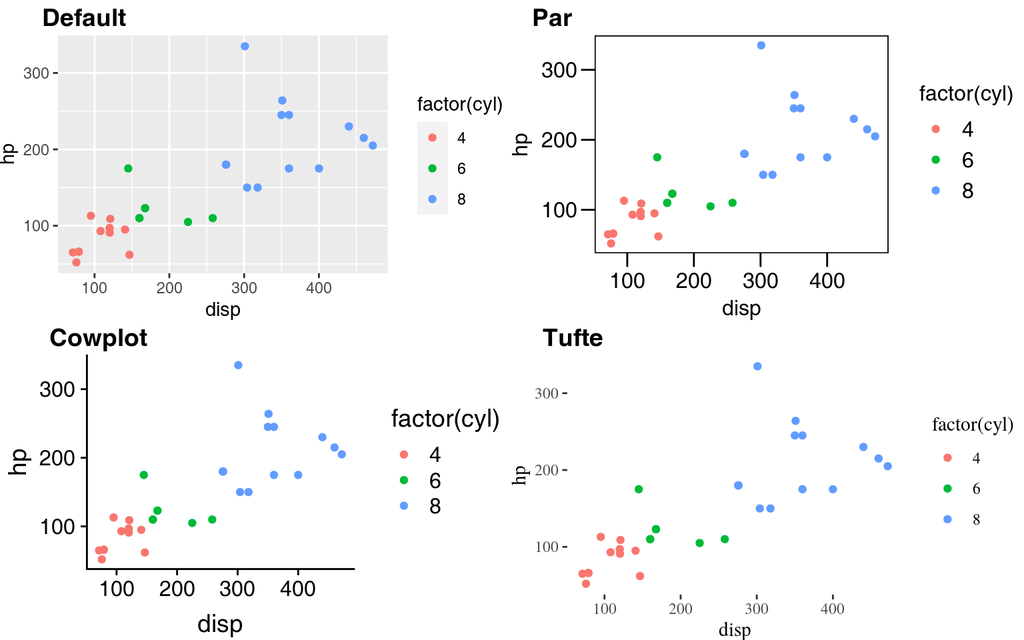

*“Above all else show the data.”* (Tufte)

## Eine kleine Farbenlehre

## Farbenlehre (Color theory)

- What is the function of color on the plot?
- Does the color help or distract?

## Representing colors

There are many ways to represent colors. In R, we most frequently use the RGB scheme in which each color is composed of three values for each of the three colors: red, green and blue.

One way is to choose values between 0 and 1; another, between 0 and 255. The latter can be represented using hexadecimal notation, in which the value goes from 0 to FF (`15 * 16 + 15 = 255`). This is a very common notation, used also in HTML:

- `"#FF0000"` or `c(255, 0, 0)`: red channel to the max, blue and green to the minimum. The result is color red.
- `"#00FF00"`: bright green
- `"#000000"`: black
- `"#FFFFFF"`: white

## Getting the colors

- To get the color from numbers in 0…1 range:

  ```
  rgb(0.5, 0.7, 0) # returns "#80B300"
  ```

- To get the color from numbers in 0…255 range:

  ```
  rgb(255, 128, 0, maxColorValue=255)
  ```

## Alpha channel: transparency

Useful way to handle large numbers of data points. `#FF000000`: fully transparent; `#FF0000FF`: fully opaque.

```r
x <- rnorm(10000)
y <- x + rnorm(10000)
p1 <- ggplot(NULL, aes(x=x, y=y)) + geom_point() +
  theme_tufte() + theme(plot.margin=unit(c(2,1,1,1), "cm"))
p2 <- ggplot(NULL, aes(x=x, y=y)) + geom_point(color="#6666661F") +
  theme_tufte() + theme(plot.margin=unit(c(2,1,1,1),"cm"))
plot_grid(p1, p2, labels=c("Black", "#6666661F"))
```

## Alpha channel: transparency

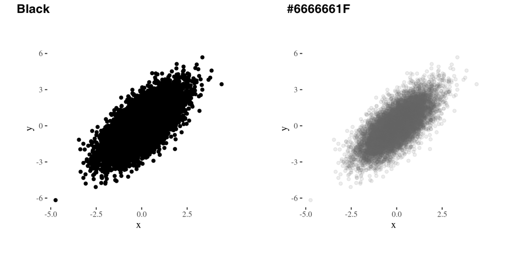

## Palettes

It is not easy to get a nice combination of colors (see default plot in ggplot2 to see how *not* to do it).

There are numerous palettes in numerous packages. One of the most popular is `RColorBrewer`. You can use it with both base R and `ggplot2`.

## RColorBrewer palettes

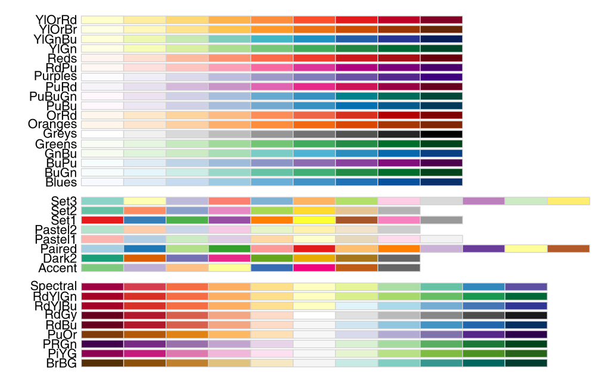

```r
library(RColorBrewer)
par(mar=c(0,4,0,0))
display.brewer.all()
```

## RColorBrewer palettes: color blind

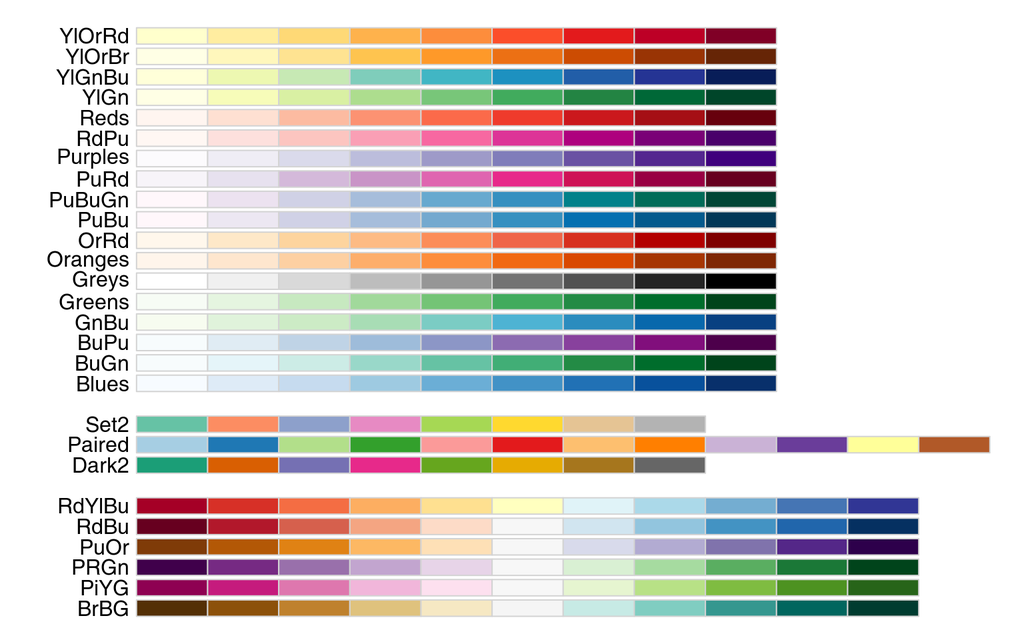

```r
par(mar=c(0,4,0,0))
display.brewer.all(colorblindFriendly=T)
```

## Iris data set

```
data("iris")
```

*The use of multiple measurements in taxonomic problems as an example of linear discriminant analysis.* Fisher 1936

## Gallery of RColorBrewer palettes

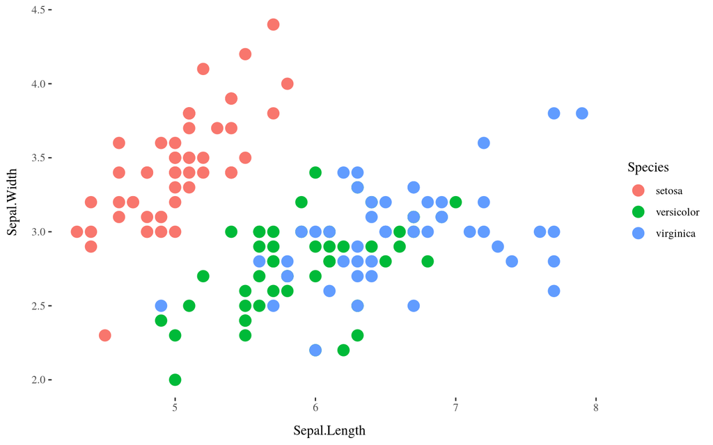

```r
ggplot(iris, aes(x=Sepal.Length, y=Sepal.Width, color=Species)) +
  geom_point(size=4) + theme_tufte() +
  theme(axis.title.y=element_text(margin=margin(0,10,0,0)),
        axis.title.x=element_text(margin=margin(10, 0, 0, 0)))
```

## Dark2

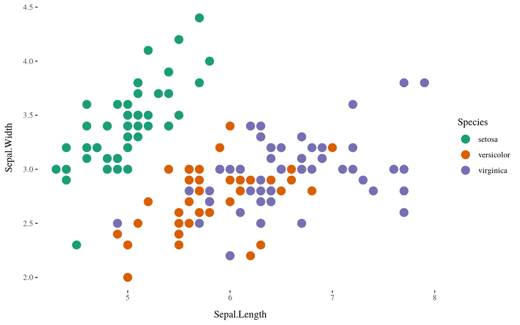

```r
ggplot(iris, aes(x=Sepal.Length, y=Sepal.Width, color=Species)) +
  geom_point(size=4) + scale_color_brewer(palette="Dark2")  + theme_tufte() +
  theme(axis.title.y=element_text(margin=margin(0,10,0,0)),
        axis.title.x=element_text(margin=margin(10, 0, 0, 0)))
```

## Paired

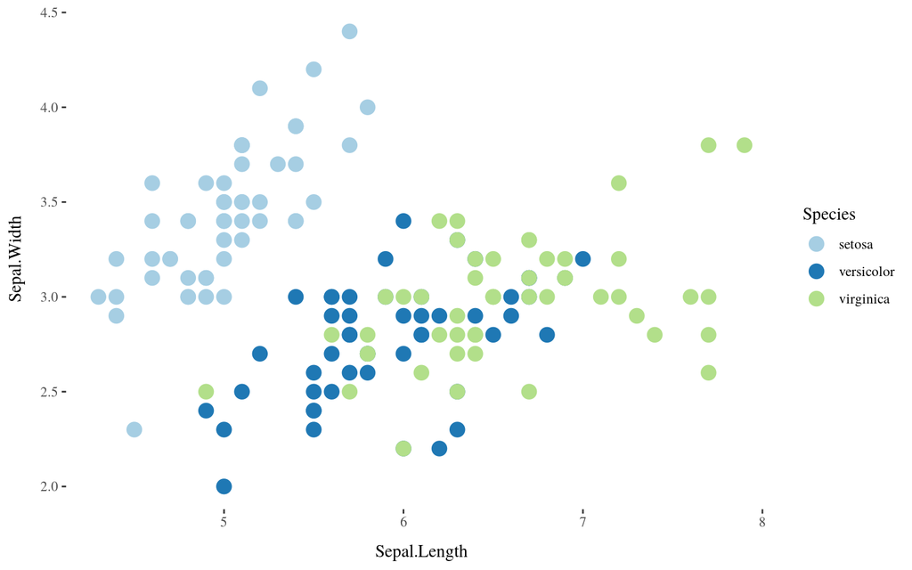

```r
ggplot(iris, aes(x=Sepal.Length, y=Sepal.Width, color=Species)) +
  geom_point(size=4) + scale_color_brewer(palette="Paired") + theme_tufte() +
  theme(axis.title.y=element_text(margin=margin(0,10,0,0)),
        axis.title.x=element_text(margin=margin(10, 0, 0, 0)))
```

## Set2

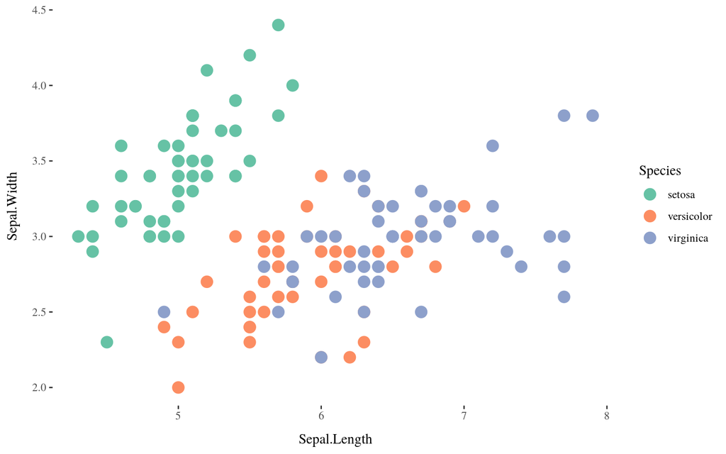

```r
ggplot(iris, aes(x=Sepal.Length, y=Sepal.Width, color=Species)) +
  geom_point(size=4) + scale_color_brewer(palette="Set2") + theme_tufte() +
  theme(axis.title.y=element_text(margin=margin(0,10,0,0)),
        axis.title.x=element_text(margin=margin(10, 0, 0, 0)))
```

## Graphics systems in R

## Important message

It is not important which system you use. It is important that you first come up with the idea how you want the data to be plotted, and that you can plot it – with whatever means you can. (Where should you look for a lost watch?)

## Graphics in basic R: Pros

- easy learning curve
- good for quick and dirty plots
- relatively easy to add arbitrary elements to the plots
- widely spread
- many specialized packages doing what otherwise cannot be easily achieved

## Graphics in basic R: Cons

- messy
- not standardized
- once you put something on the plot, it stays here
- some things are incredibly hard to achieve
- by default ugly as sin

## Graphics in ggplot2: Pros

- well thought through and organized
- easy to modify a ready made plot
- dozens of different plot types with a similar interface
- tons of ggplot2 based packages
- widely spread

## Graphics in ggplot2: Cons

- steeper learning curve
- some things are incredibly hard to achieve
- if it's not there, you are on your own
- by default ugly as sin

## Things that basic R sucks at

- changing the overall esthetics of the plot
- modifying certain parameters (like text)

## Things that ggplot2 sucks at

- networks (use igraph or graphviz for that)
- identifying points on a plot, interactive graphics
- 3D graphics

## ggplot2 overview

- mapping between variables and an "esthetics"
  - x, y
  - color, fill
  - symbol
  - ymin/ymax, xmin/xmax (error bars)
- geom (points, segments, bars, whatever)
- guides (axes, legends)
- theme (specific look of things)

## Example session

We will now use world inequality data to create a bar plot.

```r
wid <- read_excel("WIID_19Dec2018.xlsx")
wid %<>% drop_na(gini_reported, q1:q5, d1:d10)
wid2015 <- wid %>% filter(year==2015 &
                          region_un == "Europe" &
                          population > 5e6)
wid2015sel <- wid2015  %>%
  filter(quality=="High") %>%
  filter(!duplicated(country)) %>%
  select(country, gini_reported, q1:q5, d1:d10)

data <- wid2015sel %>%
  gather(q1:q5, key="quantile", value="proportion") %>%
  mutate(quantile=factor(quantile, levels=paste0("q", c(2, 1, 5, 4, 3))))

## we mess the quantiles on purpose
p <- data %>%
  ggplot(aes(country, proportion, fill=quantile)) +
  geom_bar(stat="identity") + coord_flip()
p
```

## Example session

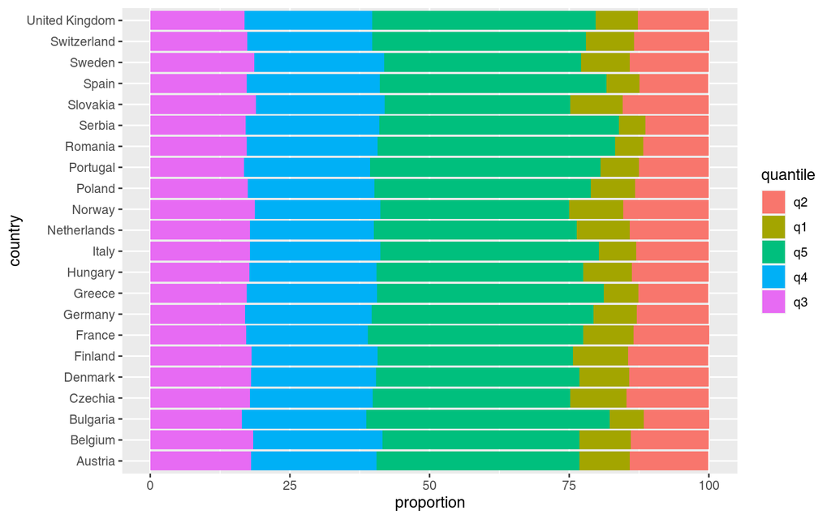

## First, reorder the quantile factor

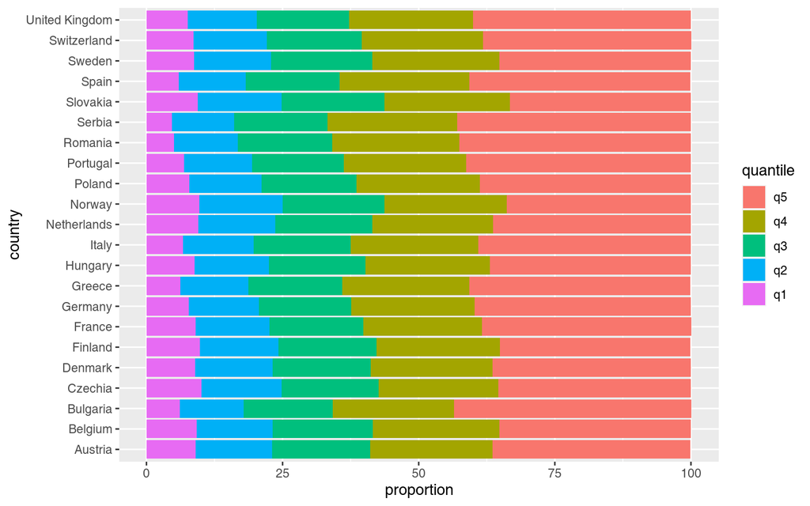

```r
data <- data %>% mutate(quantile=factor(quantile, levels=paste0("q", 5:1)))
p <- data %>%
  ggplot(aes(country, proportion, fill=quantile)) +
  geom_bar(stat="identity") + coord_flip()
p
```

## Reorder the countries

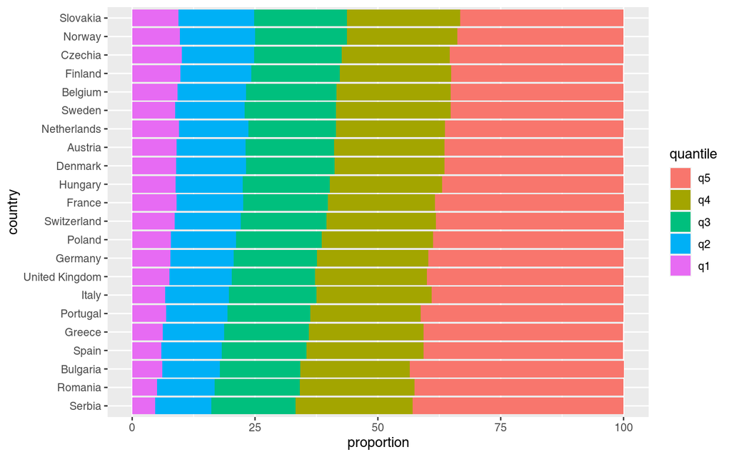

```r
data <- wid2015sel %>%
  mutate(country=reorder(country, desc(gini_reported))) %>%
  gather(q1:q5, key="quantile", value="proportion") %>%
  mutate(quantile=factor(quantile, levels=paste0("q", 5:1)))
p <- data  %>%
  ggplot(aes(country, proportion, fill=quantile)) +
  geom_bar(stat="identity") + coord_flip()
p
```

## Make it nice!

```r
p + theme_tufte() + scale_fill_brewer(palette="Blues") +
  ylab("Proportion of wealth") + xlab("Country") +
  guides(fill=guide_legend(reverse=TRUE))
```

## Make it nice!

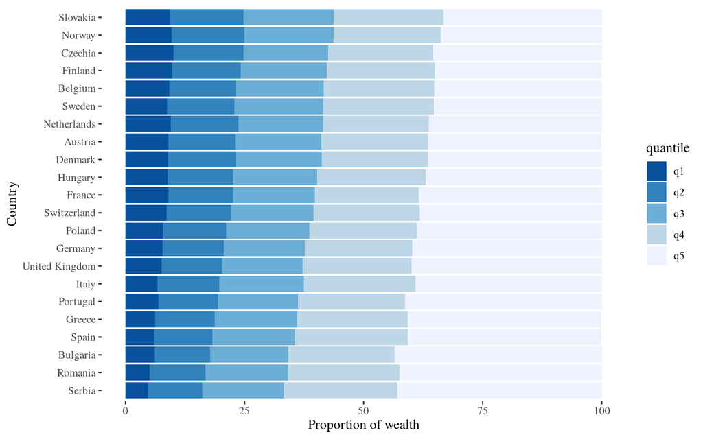

## ggplot2 tips and tricks

## Working with themes

The `theme()` and `theme_*()` functions return an object of the class `theme` which can be added to a ggplot in order to change appearance of several elements. The list of the elements you can theme can be found in the `theme()` help page. You can add themes. The result is again a theme object that you can reuse and even set as default. This makes it easy to create your own themes.

(Demo)

## Cowplot

There are two important functions in cowplot: predefined `theme_cowplot()`, which is quite nice, and `plot_grid()`, which rocks. `plot_grid` allows you to create separate plots and combine them in a number of ways. You can even draw a plot in basic R, record it and include it in your `plot_grid` call!

Note: Cowplot defines its own theme, `theme_cowplot()` and *automatically sets it when loaded*. It stays there even if you unload the package, however you can always use `theme_set()` to set the default theme to something else.

(Demo)

## `facet_grid`

You can get a lattice-like representation using `facet_grid()` function. For example:

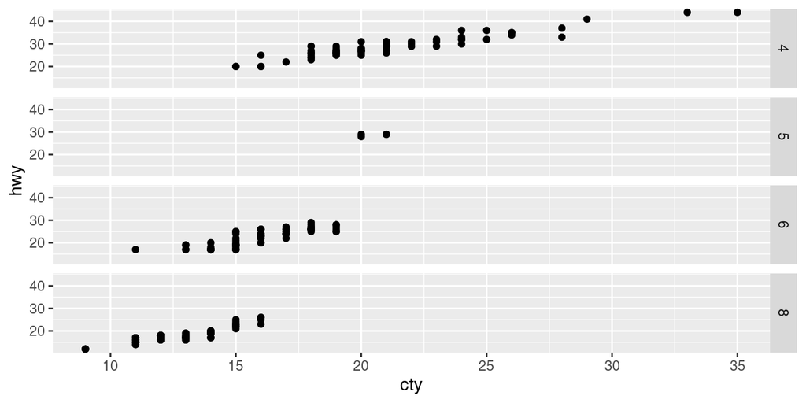

```r
ggplot(mpg, aes(cty, hwy)) + geom_point() + facet_grid(rows=mpg$cyl)
```